# Quizz Session 2

## Linear and polynomial regression models

**1. The model specified below is $Income = \beta_0 +\beta_1·Prestige + \epsilon$.**

```
Call:
lm(formula = prestige ~ income, data = Prestige)

Residuals:
    Min      1Q  Median      3Q     Max
-33.007  -8.378  -2.378   8.432  32.084

Coefficients:
             Estimate Std. Error t value Pr(>|t|)
(Intercept) 2.714e+01  2.268e+00   11.97   <2e-16 ***
income      2.897e-03  2.833e-04   10.22   <2e-16 ***
---
Signif. codes:  0 '***' 0.001 '**' 0.01 '*' 0.05 '.' 0.1 ' ' 1

Residual standard error: 12.09 on 100 degrees of freedom
Multiple R-squared:  0.5111,    Adjusted R-squared:  0.5062
F-statistic: 104.5 on 1 and 100 DF,  p-value: < 2.2e-16
```

**2. Given the summary above we can conclude that**

by increasing one unit the prestige we expext to increase 0.0029 units the income. by increasing one unit the income we expext to increase 27.14 units the prestige. by increasing one unit the income we expext to increase 0.0029 units the prestige. by increasing one unit the prestige we expext to increase 27.14 units the income.

**3. Given the previous model, we can conclude that more than $51%$ of the variability in social prestige is explained by its linear relationship with the income.**

**4. The slope of the linear model in the population is not significantly different from zero.**

**5. Given the following F-test for nested models we can conclude that is not useful including a 2nd degree polynomial for income to improve the goodness of fit of the original model. `**

```
Analysis of Variance Table

Model 1: prestige ~ income
Model 2: prestige ~ poly(income, 2)
  Res.Df   RSS Df Sum of Sq      F    Pr(>F)
1    100 14616
2     99 12077  1    2539.3 20.816 1.453e-05 ***
---
Signif. codes:  0 '***' 0.001 '**' 0.01 '*' 0.05 '.' 0.1 ' ' 1
```

**6. Choose the correct statement concerning the 2nd-degree polynomial for income:**

```
Call:
lm(formula = prestige ~ poly(income, 2), data = Prestige)

Residuals:
    Min      1Q  Median      3Q     Max
-16.963  -7.967  -2.303   7.847  32.928

Coefficients:
                 Estimate Std. Error t value Pr(>|t|)
(Intercept)        46.833      1.094  42.825  < 2e-16 ***
poly(income, 2)1  123.609     11.045  11.192  < 2e-16 ***
poly(income, 2)2  -50.391     11.045  -4.562 1.45e-05 ***
---
Signif. codes:  0 '***' 0.001 '**' 0.01 '*' 0.05 '.' 0.1 ' ' 1

Residual standard error: 11.04 on 99 degrees of freedom
Multiple R-squared:  0.596, Adjusted R-squared:  0.5879
F-statistic: 73.03 on 2 and 99 DF,  p-value: < 2.2e-16
```

The quadratic term implies a parabola bending downwards The quadratic term implies a parabola bending upwards The linear term implies a parabola bending downwards The linear term implies a parabola bending upwards

**7. Taking into account a model with income as the unique predictor of social prestige and concerning the assumptions of the linear model we can conclude that**

```
    RESET test

data:  prestige ~ poly(income, 2)
RESET = 0.051216, df1 = 2, df2 = 97, p-value = 0.9501
```

```
    studentized Breusch-Pagan test

data:  prestige ~ poly(income, 2)
BP = 0.85763, df = 2, p-value = 0.6513
```

```
    Shapiro-Wilk normality test

data:  residuals(lm(prestige ~ poly(income, 2), data = Prestige))
W = 0.95208, p-value = 0.0009972
```

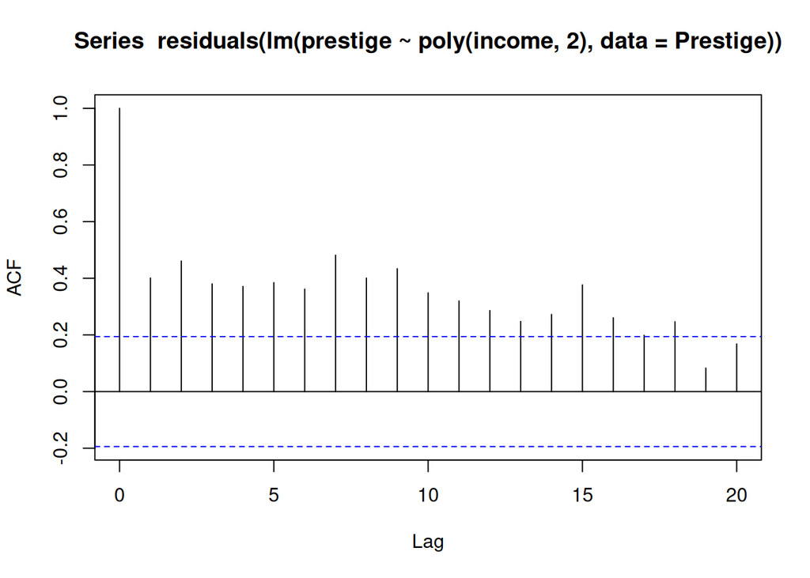

The independence and the homoscedasticity assumptions are not met. The homoscedasticity and the linearity assumptions are not met. The linearity and the normality assumptions are not met. The independence and the normality assumptions are not met.

**8. Given the outcome below we can conclude that**

```
Analysis of Variance Table

Model 1: prestige ~ income + women
Model 2: prestige ~ income * women
  Res.Df   RSS Df Sum of Sq      F    Pr(>F)
1     99 13176
2     98 10876  1      2300 20.724 1.525e-05 ***
---
Signif. codes:  0 '***' 0.001 '**' 0.01 '*' 0.05 '.' 0.1 ' ' 1
```

The fittest model is the one with only main effects of both income and women. The worst model is the one including the interaction between income and women. The fittest model is the one including the interaction between income and women. The two models are not significantly different in terms of their goodness of fit.

**9. According the model below, the expected social prestige for an individual classified as professional is: `**

```
Call:
lm(formula = prestige ~ type, data = Prestige)

Residuals:
     Min       1Q   Median       3Q      Max
-18.2273  -7.1773  -0.0854   6.1174  25.2565

Coefficients:
            Estimate Std. Error t value Pr(>|t|)
(Intercept)   35.527      1.432  24.810  < 2e-16 ***
typeprof      32.321      2.227  14.511  < 2e-16 ***
typewc         6.716      2.444   2.748  0.00718 **
---
Signif. codes:  0 '***' 0.001 '**' 0.01 '*' 0.05 '.' 0.1 ' ' 1

Residual standard error: 9.499 on 95 degrees of freedom
  (4 observations deleted due to missingness)
Multiple R-squared:  0.6976,    Adjusted R-squared:  0.6913
F-statistic: 109.6 on 2 and 95 DF,  p-value: < 2.2e-16
```

**10. By visualizing the grouped scatterplot below we can guess that an interaction between type and income variables is needed in the linear model. `**

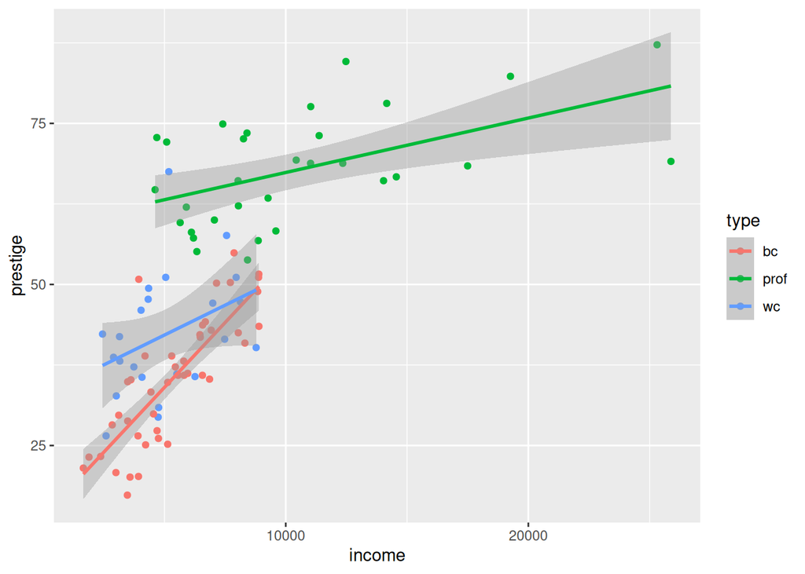